# sample code

Lucas Boyd

4/4/2022

## R Markdown

The first step is to read in some data. Here, I’ve chosen the Lake Cachuma station from the National Centers for Environmental Information website: https://www.ncdc.noaa.gov/cdo-web/datatools/findstation

A brief note: The read.table command loads the CSV file provided by NCDC into a table structure in R, here called ‘clim’; the as.Date command then transforms the DATE field in that table into an R-formatted date array that R knows how to do things with.

```r
library(lubridate)
```

```r
library(ggplot2)
library(tidyverse)
library(chron)
library(here)
clim = read.table(here("CachumaLake_NCDC_USC00041253.csv"),fill=TRUE,sep=',',header=T)
head(clim)
```

```
##       STATION                NAME       DATE DAPR MDPR PRCP SNOW SNWD TMAX TMIN
## 1 USC00041253 CACHUMA LAKE, CA US 1952-03-01   NA   NA 0.22   NA   NA   NA   NA
## 2 USC00041253 CACHUMA LAKE, CA US 1952-03-02   NA   NA 0.00   NA   NA   NA   NA
## 3 USC00041253 CACHUMA LAKE, CA US 1952-03-03   NA   NA 0.06   NA   NA   NA   NA
## 4 USC00041253 CACHUMA LAKE, CA US 1952-03-04   NA   NA 0.00   NA   NA   NA   NA
## 5 USC00041253 CACHUMA LAKE, CA US 1952-03-05   NA   NA 0.00   NA   NA   NA   NA
## 6 USC00041253 CACHUMA LAKE, CA US 1952-03-06   NA   NA 2.01   NA   NA   NA   NA
##   TOBS
## 1   NA
## 2   NA
## 3   NA
## 4   NA
## 5   NA
## 6   NA
```

```r
date=as.Date(clim$DATE)
```

Now that we’ve read in the data, the next step is quality checking! Let’s make a plot to see what data are missing.

Lets start with daily data of air temperature

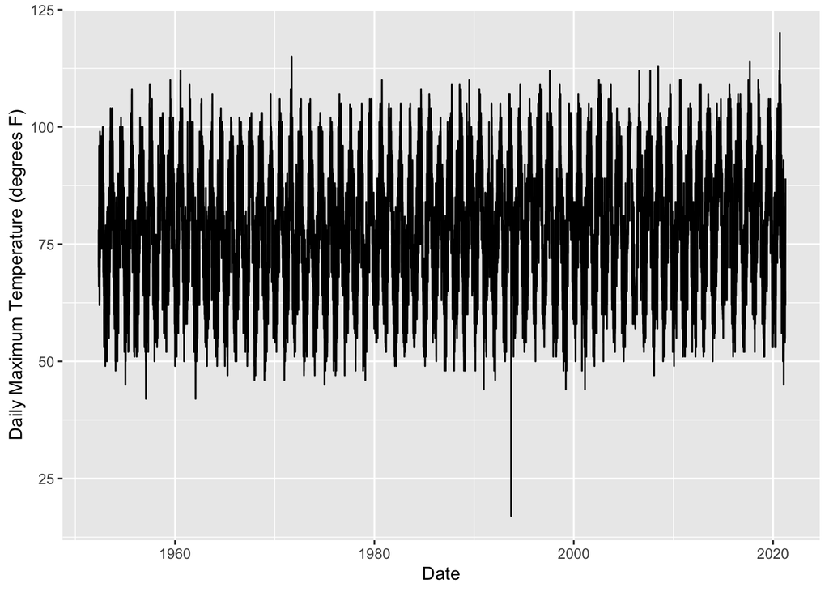

```r
ggplot(clim, aes(date, clim$TMAX))+geom_line()+ labs(y="Daily Maximum Temperature (degrees F)", x="Date")
```

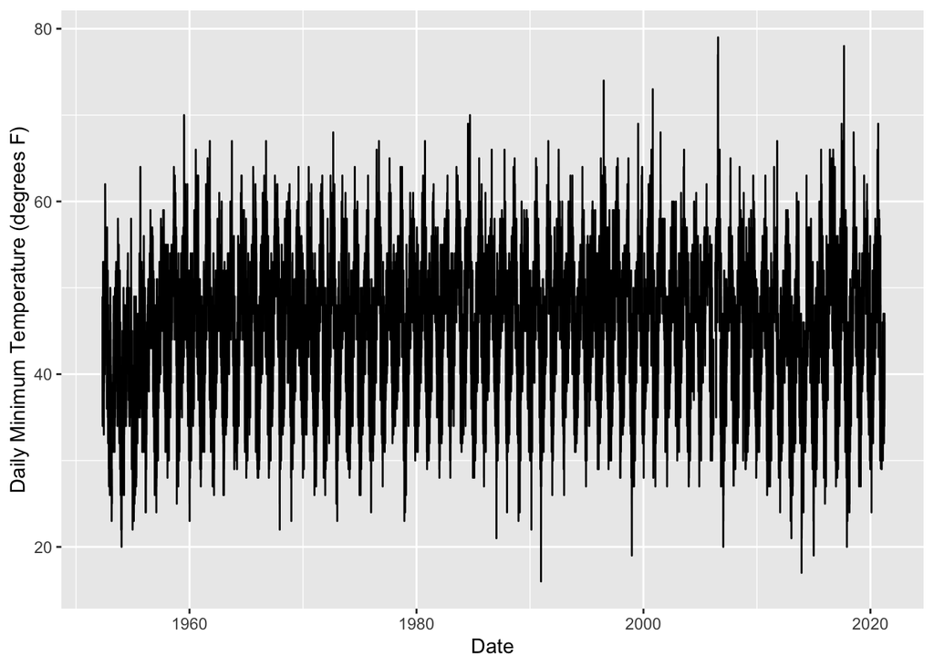

```r
ggplot(clim, aes(date, clim$TMIN))+geom_line()+ labs(y="Daily Minimum Temperature (degrees F)", x="Date")
```

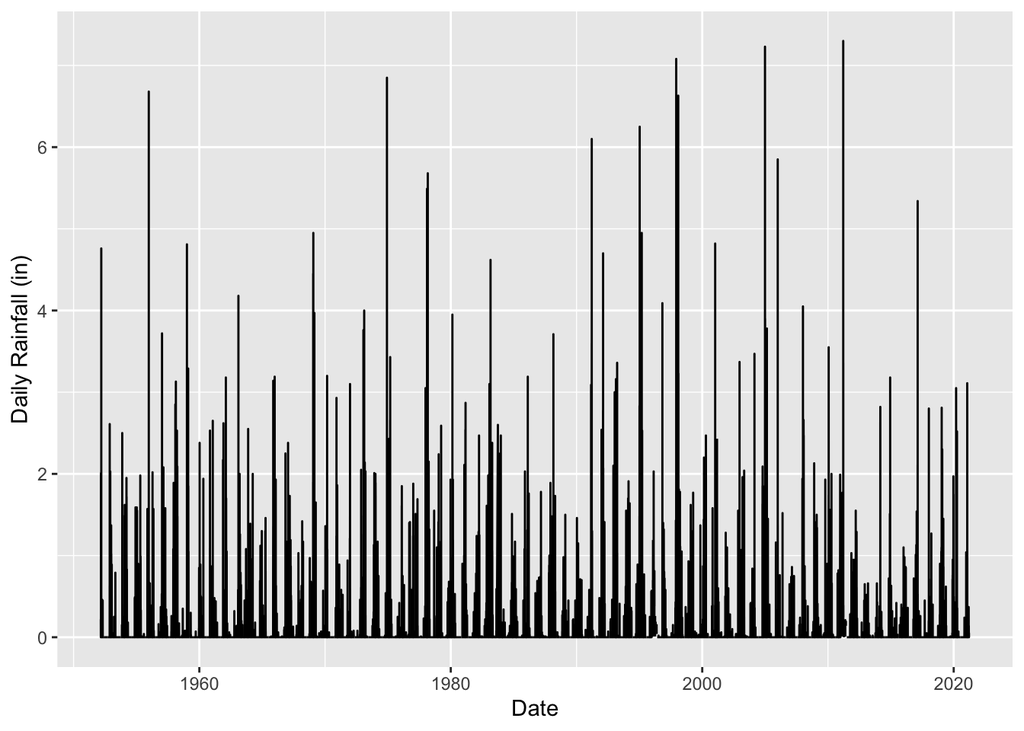

```r
ggplot(clim, aes(date, clim$PRCP))+geom_line()+ labs(y="Daily Rainfall (in)", x="Date")
```

Some values are “NA” in temperature and precipitation; these have been trimmed automatically by ggplot, but this may not be the case for all functions. In general, you’ll want to check meta data to see how missing data is labelled: -999 or NA are common choices.

To fill - if < 0.5 percent of data is missing there are some very simple ways to fill but you must remember that you are doing this!!!

- **Temperature** Average of the previous and following day
- **Precip** For dry places like the Sierra, assume no rain where data is missing (This may not be a good assumption in other places! be careful.)

```r
# find the row with missing data
fillrow = which(is.na(clim$PRCP))
fillrow
```

```
##   [1]   274  2144  2145 11509 12241 12298 12386 12387 12388 12875 15063 15920
##  [13] 15921 15922 15923 15924 15925 15926 15927 15928 15929 15930 15931 15932
##  [25] 15933 15934 15935 15937 15939 15942 15943 15946 15948 15949 15952 15957
##  [37] 15958 15959 15960 15961 15962 15963 15964 15965 15967 15968 15973 15974
##  [49] 15977 15981 15982 15986 15987 15988 15989 15990 15994 15995 15996 15997
##  [61] 15998 15999 16001 16002 16003 16004 16005 16006 16008 16009 16010 16011
##  [73] 16014 16015 16016 16017 16018 16019 16020 16021 16022 16023 16024 16025
##  [85] 16026 16029 16030 16031 16032 16033 16034 16035 16036 16037 16038 16039
##  [97] 16040 16041 16042 16043 16044 16045 16046 16047 16048 16049 16050 16051
## [109] 16052 16053 16054 16055 16058 16059 16060 16061 16062 16063 16064 16065
## [121] 16066 16067 16068 16069 16070 16071 17810 19268 19269 19270 19271 19272
## [133] 19273 19274 19275 19276 19277 19278 19279 19280 19281 19282 19283 19284
## [145] 19285 19286 19287 19288 19289 19290 19291 19292 19293 19294 19295 19296
## [157] 19297 21251 21255 21256 21257 21258 21259 21260 21261 21262 21263 21264
## [169] 21265 21266 21267 21268 21269 21270 21271 21272 21273 21274 21275 21276
## [181] 21277 21278 21279 21282 21283 21284 21285 21286 21287 21288 21289 21290
## [193] 21291 21292 21293 21294 21295 21302 21303 21304 21305 21308 21309 21310
## [205] 21314 21315 21317 21318 21319 21320 21321 21322 21323 21324 21325 21326
## [217] 21327 21335 21337 21338 21339 21340 21341 21342 21343 21344 21345 21346
## [229] 21350 21351 21352 21353 21354 21355 21356 21357 21358 21359 21361 21363
## [241] 21364 21365 21366 21367 21368 21369 21371 21372 21373 21374 21375 21376
## [253] 21377 21378 21379 21380 21381 21382 21383 21389 21390 21391 21392 21393
## [265] 21394 21395 21396 21397 21398 21399 21400 21401 21402 21403 21404 21407
## [277] 21408 21409 21410 21411 21412 21413 21414 21415 21416 21417 21418 21419
## [289] 21420 21421 21422 21423 21424 21425 21426 21427 21428 21429 21430 24989
```

[figure not shown]

```r
clim$PRCP[fillrow]=0
# replot to make sure it works
ggplot(clim, aes(date, clim$PRCP))+geom_line()+ labs(y="Daily rainfall (mm)", x="Date")
```

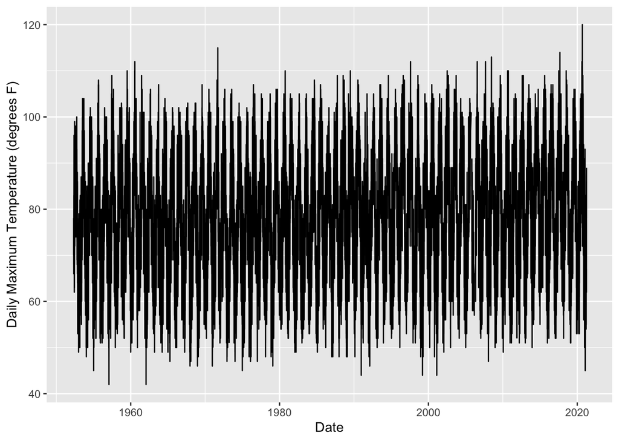

```r
# find rows with missing data
# temperature
fillrow = which(is.na(clim$TMAX) | clim$TMAX < 40)
fillrow = fillrow[2:length(fillrow)]
clim$TMAX[fillrow]=(clim$TMAX[fillrow+1]+clim$TMAX[fillrow-1])/2
ggplot(clim, aes(date, clim$TMAX))+geom_line()+ labs(y="Daily Maximum Temperature (degrees F)", x="Date")
```

**Is there a trend?**

Trends can be ‘swamped’ by variation; in this case, the seasonal cycle is quite large. We also need to consider autocorrelation!

So here let’s try doing some aggregation to reduce the noise. As a simple example, we can try annual averages.

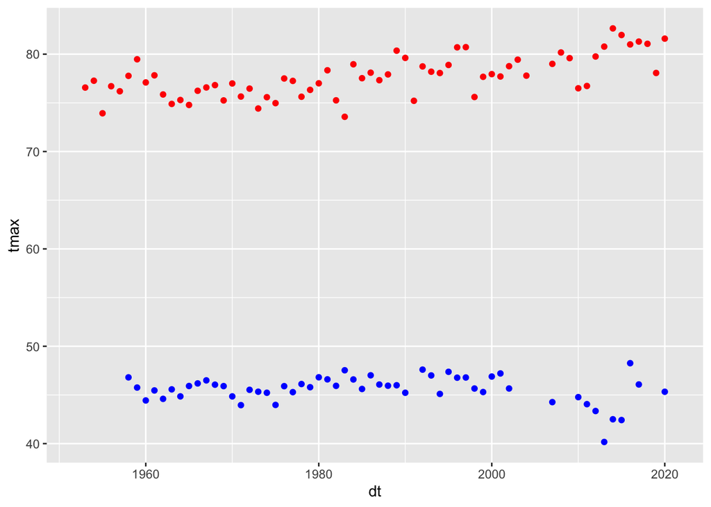

```r
clim.mwy = clim %>% group_by(year(date)) %>% summarize(tmax=mean(TMAX), tmin=mean(TMIN), precip=sum(PRCP))
clim.mwy$dt = unique(year(date))

ggplot(clim.mwy, aes(x=dt, tmax))+geom_point(col="red")+
  scale_y_continuous(limits=c(min(clim.mwy$tmin), max(clim.mwy$tmax)))+
geom_point(data=clim.mwy, aes(x=dt, tmin), col="blue")
```

```r
a = ggplot(clim.mwy, aes(x=dt, tmax))+geom_point(col="red")+
  scale_y_continuous(limits=c(min(clim.mwy$tmin), max(clim.mwy$tmax)))+
geom_point(data=clim.mwy, aes(x=dt, tmin), col="blue")
```

Notice the different behavior of the min and max temperatures!

OK now let’s put a trend line on this thing.

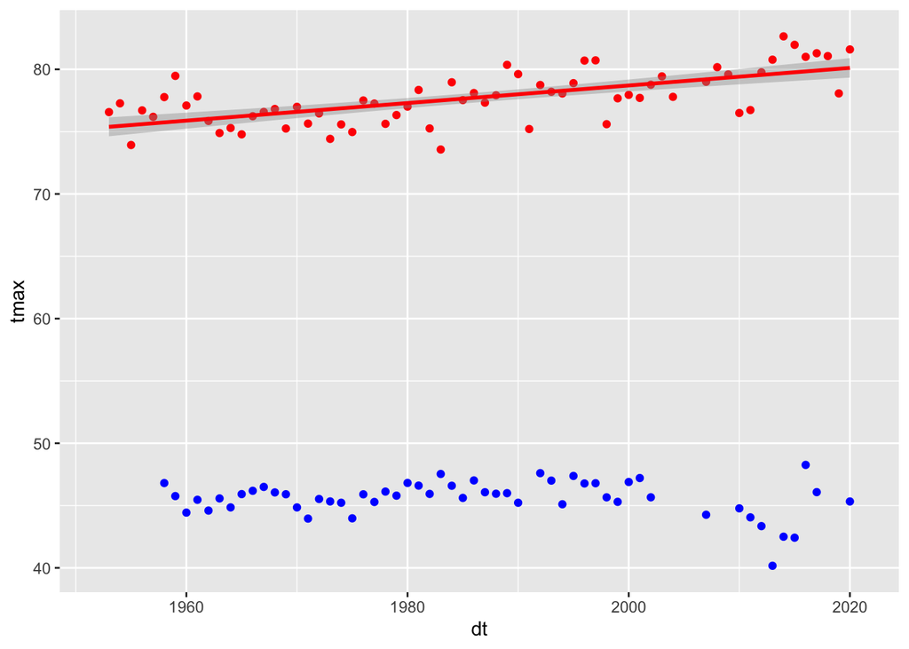

```r
# now lets add a trend line
a =a+stat_smooth(method="lm", col="red")
a
```

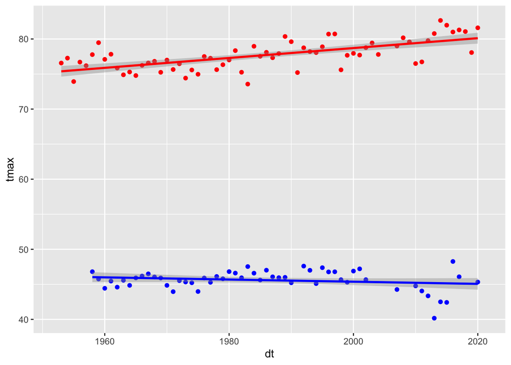

```r
a+ stat_smooth(data=clim.mwy, aes(x=dt,tmin), col="blue", method="lm")
```

Now let’s calculate the slope (or how quickly temperatures are rising; we do this with linear regression)

```r
res=lm(tmin~dt, data=clim.mwy)
summary(res)
```

```
##
## Call:
## lm(formula = tmin ~ dt, data = clim.mwy)
##
## Residuals:
##     Min      1Q  Median      3Q     Max
## -5.0033 -0.5015  0.1254  0.8938  3.1356
##
## Coefficients:
##             Estimate Std. Error t value Pr(>|t|)
## (Intercept) 76.33505   21.36245   3.573 0.000771 ***
## dt          -0.01548    0.01076  -1.439 0.156082
## ---
## Signif. codes:  0 '***' 0.001 '**' 0.01 '*' 0.05 '.' 0.1 ' ' 1
##
## Residual standard error: 1.397 on 52 degrees of freedom
##   (16 observations deleted due to missingness)
## Multiple R-squared:  0.03831,    Adjusted R-squared:  0.01981
## F-statistic: 2.071 on 1 and 52 DF,  p-value: 0.1561
```

```r
confint(res,"dt", level=0.95)
```

```
##          2.5 %      97.5 %
## dt -0.03706402 0.006103354
```

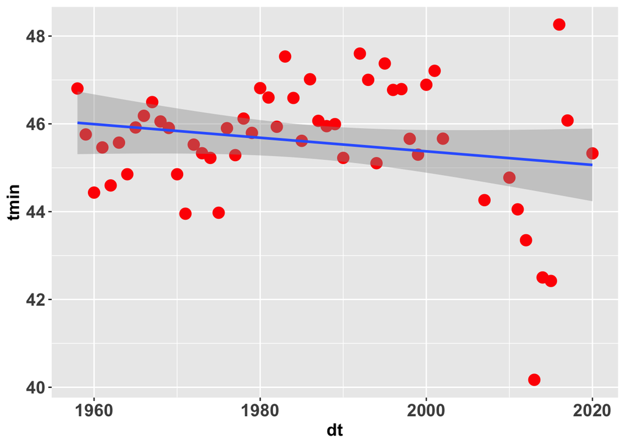

```r
ggplot(clim.mwy, aes(x=dt, y=tmin)) + stat_summary(fun.y="mean", geom="point", col="red", size=4)+theme(axis.text=element_text(size=14, face="bold"), axis.title=element_text(size=14, face="bold")) + geom_smooth(method="lm")
```

The slope on a linear regression between Tmin and wy is the rate of increase in Tmin (mean annual daily minimum temperature).

The value of the slope is -0.015 F/year, and is not statistically significant.

Let’s do the same analysis for the MAXIMUM temperature now…

```r
res=lm(tmax~dt, data=clim.mwy)
summary(res)
```

```
##
## Call:
## lm(formula = tmax ~ dt, data = clim.mwy)
##
## Residuals:
##    Min     1Q Median     3Q    Max
## -3.938 -1.054  0.118  1.142  3.662
##
## Coefficients:
##               Estimate Std. Error t value Pr(>|t|)
## (Intercept) -62.376358  19.684543  -3.169  0.00235 **
## dt            0.070540   0.009912   7.117 1.16e-09 ***
## ---
## Signif. codes:  0 '***' 0.001 '**' 0.01 '*' 0.05 '.' 0.1 ' ' 1
##
## Residual standard error: 1.581 on 64 degrees of freedom
##   (4 observations deleted due to missingness)
## Multiple R-squared:  0.4418, Adjusted R-squared:  0.4331
## F-statistic: 50.65 on 1 and 64 DF,  p-value: 1.159e-09
```

```r
confint(res,"dt", level=0.95)
```

```
##         2.5 %    97.5 %
## dt 0.05073972 0.0903409
```

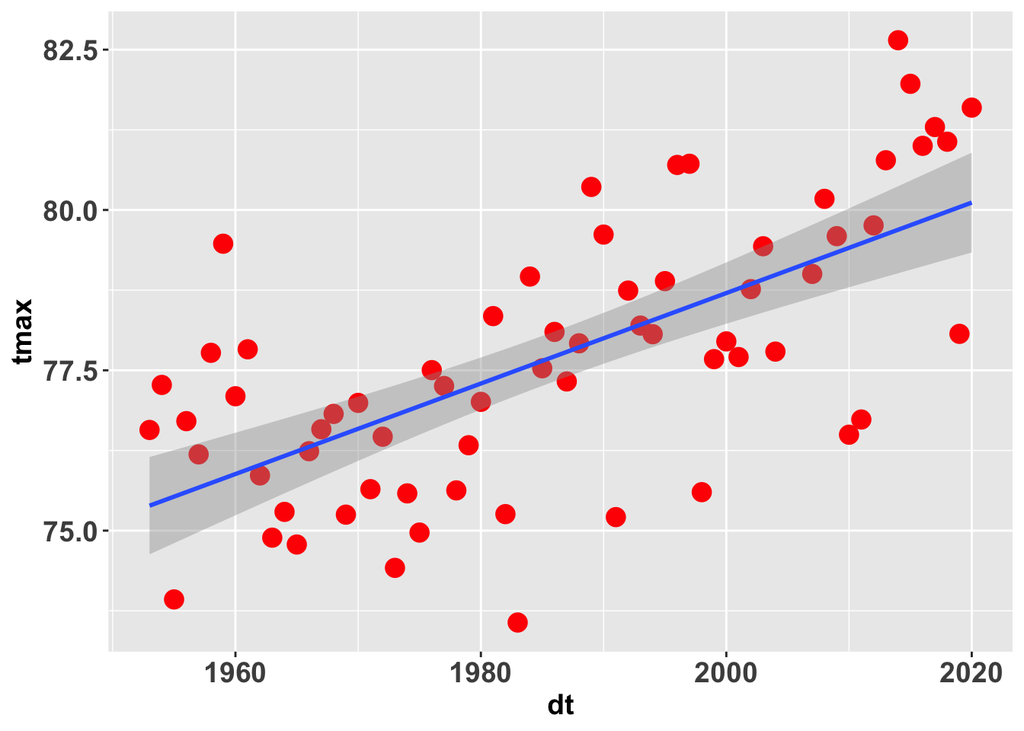

```r
ggplot(clim.mwy, aes(x=dt, y=tmax)) + stat_summary(fun.y="mean", geom="point", col="red", size=4)+theme(axis.text=element_text(size=14, face="bold"), axis.title=element_text(size=14, face="bold")) + geom_smooth(method="lm")
```

Now we find a positive trend: 0.071F/year, or 0.71F/decade. But notice that there seem to be some outliers toward the end of the record…

We might also cut the data into specific periods and see how the slope is changing as a function of time.

```r
# early portion
res_early=lm(tmin~dt, data=subset(clim.mwy, clim.mwy$dt %in% c(1952:1970)))
summary(res_early)
```

```
##
## Call:
## lm(formula = tmin ~ dt, data = subset(clim.mwy, clim.mwy$dt %in%
##     c(1952:1970)))
##
## Residuals:
##     Min      1Q  Median      3Q     Max
## -1.1264 -0.7549  0.2097  0.4008  1.2679
##
## Coefficients:
##              Estimate Std. Error t value Pr(>|t|)
## (Intercept)  22.76781  111.90909   0.203    0.842
## dt            0.01163    0.05698   0.204    0.842
##
## Residual standard error: 0.7687 on 11 degrees of freedom
##   (6 observations deleted due to missingness)
## Multiple R-squared:  0.003772,   Adjusted R-squared:  -0.08679
## F-statistic: 0.04165 on 1 and 11 DF,  p-value: 0.842
```

```r
confint(res_early,"dt", level=0.90)
```

```
##           5 %      95 %
## dt -0.0907006 0.1139587
```

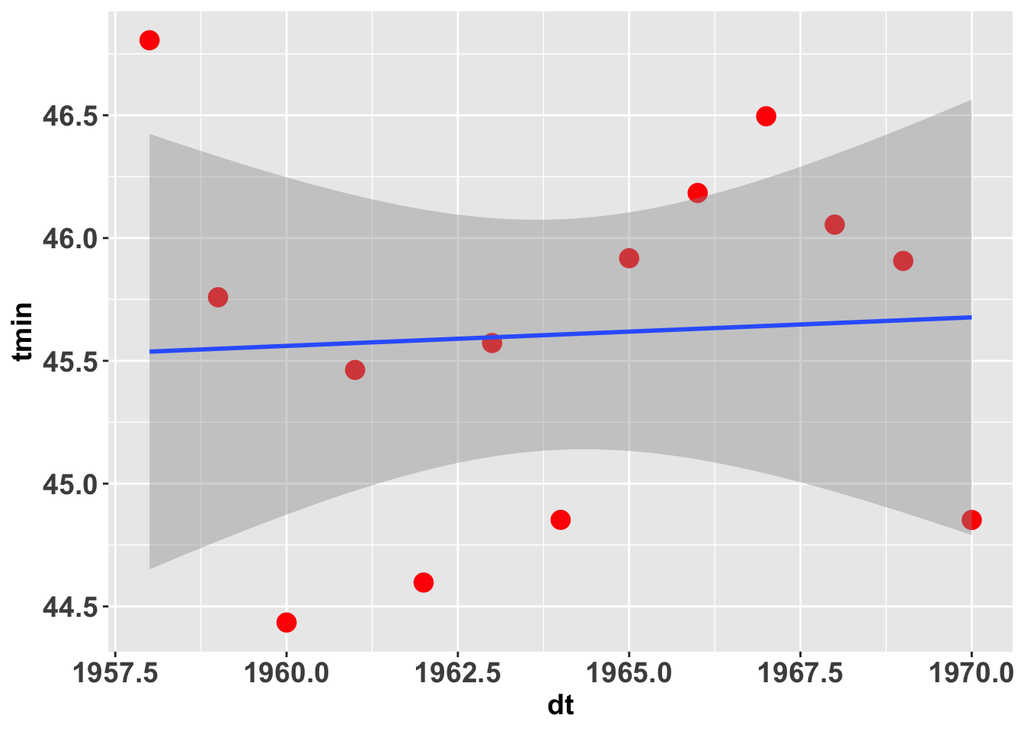

```r
ggplot(subset(clim.mwy, clim.mwy$dt %in% c(1952:1970)), aes(x=dt, y=tmin)) + stat_summary(fun.y="mean", geom="point", col="red", size=4)+theme(axis.text=element_text(size=14, face="bold"), axis.title=element_text(size=14, face="bold")) + geom_smooth(method="lm")
```

```r
# last decade
res_late=lm(tmin~dt, data=subset(clim.mwy, clim.mwy$dt %in% c(1995:2021)))
summary(res_late)
```

```
##
## Call:
## lm(formula = tmin ~ dt, data = subset(clim.mwy, clim.mwy$dt %in%
##     c(1995:2021)))
##
## Residuals:
##     Min      1Q  Median      3Q     Max
## -4.2556 -0.8554 -0.0389  0.8913  4.1937
##
## Coefficients:
##             Estimate Std. Error t value Pr(>|t|)
## (Intercept) 283.8850   110.5825   2.567   0.0207 *
## dt           -0.1190     0.0551  -2.159   0.0464 *
## ---
## Signif. codes:  0 '***' 0.001 '**' 0.01 '*' 0.05 '.' 0.1 ' ' 1
##
## Residual standard error: 1.884 on 16 degrees of freedom
##   (9 observations deleted due to missingness)
## Multiple R-squared:  0.2256, Adjusted R-squared:  0.1772
## F-statistic: 4.661 on 1 and 16 DF,  p-value: 0.0464
```

```r
confint(res_late,"dt", level=0.90)
```

```
##           5 %        95 %
## dt -0.2151591 -0.02275394
```

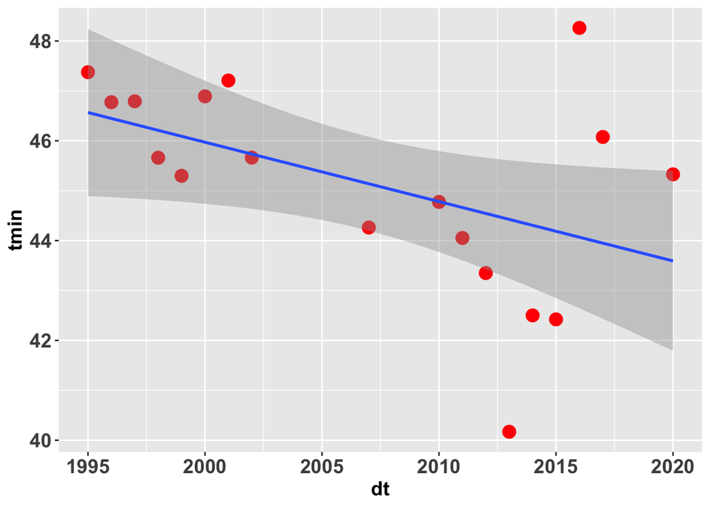

```r
ggplot(subset(clim.mwy, clim.mwy$dt %in% c(1995:2021)), aes(x=dt, y=tmin)) + stat_summary(fun.y="mean", geom="point", col="red", size=4)+theme(axis.text=element_text(size=14, face="bold"), axis.title=element_text(size=14, face="bold")) + geom_smooth(method="lm")
```

Regression assumes a linear relationship - and normally distributed data - sometimes that isn’t true, we can use non-parameteric tests to look for trends. In these cases, the Mann-Kendall test is commonly used.

tau ranges from -1 to 1 and denotes the “strength” of the trend; p-value denotes significance. Strength however can not be interpreted as slope!

```r
library(Kendall)
MannKendall(clim.mwy$tmin)
```

```
## tau = 0.0028, 2-sided pvalue =0.98214
```

```r
MannKendall(clim.mwy$tmax)
```

```
## tau = 0.479, 2-sided pvalue =< 2.22e-16
```

```r
MannKendall(clim.mwy$precip)
```

```
## tau = -0.024, 2-sided pvalue =0.7726
```

We might also look at difference in means (or variance) between the two periods …Using

T-test (if we think the data is normally distributed) or Rank-Sum if we do not.

```r
t.test(subset(clim.mwy$tmin, clim.mwy$dt %in% 1953:1969), subset(clim.mwy$tmin, clim.mwy$dt %in% 1995:2004))
```

```
##
##  Welch Two Sample t-test
##
## data:  subset(clim.mwy$tmin, clim.mwy$dt %in% 1953:1969) and subset(clim.mwy$tmin, clim.mwy$dt %in% 1995:2004)
## t = -2.2398, df = 14.275, p-value = 0.04151
## alternative hypothesis: true difference in means is not equal to 0
## 95 percent confidence interval:
##  -1.54003753 -0.03477783
## sample estimates:
## mean of x mean of y
##  45.67024  46.45765
```

```r
wilcox.test(subset(clim.mwy$tmin, clim.mwy$dt %in% 1953:1969), subset(clim.mwy$tmin, clim.mwy$dt %in% 1995:2004))
```

```
##
##  Wilcoxon rank sum exact test
##
## data:  subset(clim.mwy$tmin, clim.mwy$dt %in% 1953:1969) and subset(clim.mwy$tmin, clim.mwy$dt %in% 1995:2004)
## W = 25, p-value = 0.0825
## alternative hypothesis: true location shift is not equal to 0
```

```r
# create a variable
clim$season = ifelse(month(date) %in% c(12,1,2), 1, ifelse(month(date) %in% c(3:5),2, ifelse(month(date) %in% c(6:8),3,4)))
clim.byseason = clim %>% group_by(year(date),season) %>% summarize(tmax=mean(TMAX), tmin=mean(TMIN), precip=sum(PRCP))
```

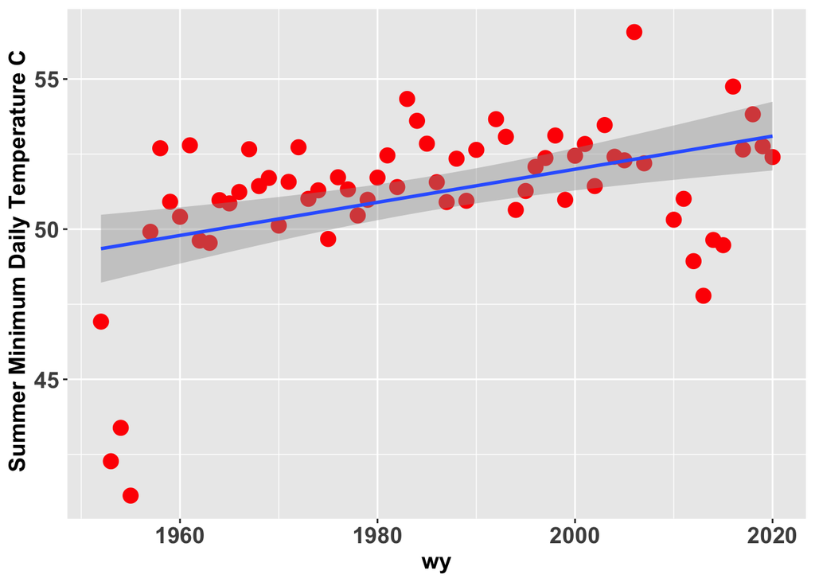

```r
# look only at summer
clim.summer = subset(clim.byseason, clim.byseason$season==3)
tmp=unique(year(date))
clim.summer$wy = tmp[1:length(tmp)-1]

ggplot(clim.summer, aes(x=wy, y=tmin)) + stat_summary(fun.y="mean", geom="point", col="red", size=4)+theme(axis.text=element_text(size=14, face="bold"), axis.title=element_text(size=14, face="bold")) + geom_smooth(method="lm")+labs(y=" Summer Minimum Daily Temperature C")
```

```r
res=lm(tmax~wy, data=clim.summer)
summary(res)
```

```
##
## Call:
## lm(formula = tmax ~ wy, data = clim.summer)
##
## Residuals:
##      Min       1Q   Median       3Q      Max
## -10.1912  -1.2309   0.0603   1.0052   3.8161
##
## Coefficients:
##              Estimate Std. Error t value Pr(>|t|)
## (Intercept) -58.36898   27.81002  -2.099   0.0396 *
## wy            0.07422    0.01400   5.300 1.39e-06 ***
## ---
## Signif. codes:  0 '***' 0.001 '**' 0.01 '*' 0.05 '.' 0.1 ' ' 1
##
## Residual standard error: 2.317 on 67 degrees of freedom
## Multiple R-squared:  0.2954, Adjusted R-squared:  0.2849
## F-statistic: 28.09 on 1 and 67 DF,  p-value: 1.392e-06
```

```r
confint(res,"wy", level=0.95)
```

```
##         2.5 %    97.5 %
## wy 0.04626855 0.1021661
```

Notice how the trends in summer minimum temperature differ from the annual minimum temperature trend!